# DAND_P2_python

泰坦尼克是我们熟悉的电影，除了它的浪漫爱情故事，作为数据分析师，关注更多的可能是哪些乘客在这次灾难中幸存下来？幸存者有什么特别的特征？是否跟他的性别有关？是否与年龄有关？或者阶层？

## 1、首先读取并查看数据

```python
## 读取文件并查看数据
import pandas as pd
import numpy as np
import matplotlib.pyplot as plt
titanic_data = pd.read_csv('titanic-data.csv')
titanic_data.head()
```

|  | PassengerId | Survived | Pclass | Name | Sex | Age | SibSp | Parch | Ticket | Fare | Cabin | Embarked |
| --- | --- | --- | --- | --- | --- | --- | --- | --- | --- | --- | --- | --- |
| 0 | 1 | 0 | 3 | Braund, Mr. Owen Harris | male | 22.0 | 1 | 0 | A/5 21171 | 7.2500 | NaN | S |
| 1 | 2 | 1 | 1 | Cumings, Mrs. John Bradley (Florence Briggs Th... | female | 38.0 | 1 | 0 | PC 17599 | 71.2833 | C85 | C |
| 2 | 3 | 1 | 3 | Heikkinen, Miss. Laina | female | 26.0 | 0 | 0 | STON/O2. 3101282 | 7.9250 | NaN | S |
| 3 | 4 | 1 | 1 | Futrelle, Mrs. Jacques Heath (Lily May Peel) | female | 35.0 | 1 | 0 | 113803 | 53.1000 | C123 | S |
| 4 | 5 | 0 | 3 | Allen, Mr. William Henry | male | 35.0 | 0 | 0 | 373450 | 8.0500 | NaN | S |

```python
## 查看数据的总体情况
titanic_data.describe()
```

|  | PassengerId | Survived | Pclass | Age | SibSp | Parch | Fare |
| --- | --- | --- | --- | --- | --- | --- | --- |
| count | 891.000000 | 891.000000 | 891.000000 | 714.000000 | 891.000000 | 891.000000 | 891.000000 |
| mean | 446.000000 | 0.383838 | 2.308642 | 29.699118 | 0.523008 | 0.381594 | 32.204208 |
| std | 257.353842 | 0.486592 | 0.836071 | 14.526497 | 1.102743 | 0.806057 | 49.693429 |
| min | 1.000000 | 0.000000 | 1.000000 | 0.420000 | 0.000000 | 0.000000 | 0.000000 |
| 25% | 223.500000 | 0.000000 | 2.000000 | 20.125000 | 0.000000 | 0.000000 | 7.910400 |
| 50% | 446.000000 | 0.000000 | 3.000000 | 28.000000 | 0.000000 | 0.000000 | 14.454200 |
| 75% | 668.500000 | 1.000000 | 3.000000 | 38.000000 | 1.000000 | 0.000000 | 31.000000 |
| max | 891.000000 | 1.000000 | 3.000000 | 80.000000 | 8.000000 | 6.000000 | 512.329200 |

从表中可以看出，Age列有缺失值，其他列都是891条记录，而Age列只有714条记录。另外，由于是否生还是用O和1表示，那么均值就是其总的生还率，即38.38%。

## 2、其次探索数据

### 2.1性别与生还率

```python
## 电影中救生艇那段，‘妇女和孩子先上船’，让我们来看看是否生还者里面女性多于男性，年龄小的多于年龄大的？先看性别。
titanic_by_sex = titanic_data.groupby('Sex')['Survived'].count()
titanic_by_sex
```

```
Sex
female    314
male      577
Name: Survived, dtype: int64
```

计数count表示男性和女性的总人数。

```python
## 生还的男女数量
titanic_by_survive = titanic_data.groupby('Sex')['Survived'].sum()
titanic_by_survive
```

```
Sex
female    233
male      109
Name: Survived, dtype: int64
```

```python
## 用sum和count的比值来计算男性和女性的生还率。也就是均值。
group_by_sex = titanic_data.groupby('Sex')['Survived'].mean()
group_by_sex
```

```
Sex
female    0.742038
male      0.188908
Name: Survived, dtype: float64
```

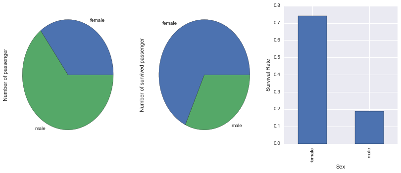

```python
## 将男女总人数、生还数量及生还率用柱状图表示

plt.figure(figsize=(14,5))
plt.subplot(1,3,1)
titanic_data.groupby('Sex')['Survived'].count().plot(kind='pie')
plt.ylabel('Number of passenger')
plt.subplot(1,3,2)
titanic_data.groupby('Sex')['Survived'].sum().plot(kind='pie')
plt.ylabel('Number of survived passenger')
plt.subplot(1,3,3)
titanic_data.groupby('Sex')['Survived'].mean().plot(kind='bar')
plt.ylabel('Survival Rate')
```

从图中可以看出，男性乘客总人数接近女性的两倍（左图），但是生还者中男性人数还不到女性人数的一半（中图），从右图可以看到，女性的生还率远高于男性。

### 2.2年龄与生还率

从之前的总表描述可以看出，年龄数据有缺失，先填充有缺失值的记录。此处用中值填充。

```python
## 填充年龄中的缺失值，用titanic_age代表填充年龄缺失值后的数据。
titanic_data['Adjusted_age'] = titanic_data['Age'].fillna(titanic_data['Age'].median())
titanic_data['Adjusted_age'].describe()
```

```
count    891.000000
mean      29.361582
std       13.019697
min        0.420000
25%       22.000000
50%       28.000000
75%       35.000000
max       80.000000
Name: Adjusted_age, dtype: float64
```

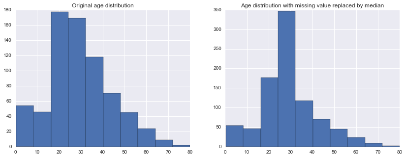

```python
## 用直方图查看年龄分布情况。将补充缺失值前后的分布情况都展示出来。
%pylab inline
plt.figure(figsize=(14,5))
plt.subplot(1,2,1)
titanic_data['Age'].hist()
plt.title('Original age distribution')
plt.subplot(1,2,2)
titanic_data['Adjusted_age'].hist()
plt.title('Age distribution with missing value replaced by median')
```

可以看出，大部分乘客年龄在20-40之间。补充缺失值后年龄的分布更加集中。

```python
## 将年龄分组，每隔10岁分为一组
bins = np.arange(0,80,10)
titanic_data['Age_group'] = pd.cut(titanic_data['Adjusted_age'],bins)
By_age = titanic_data.groupby('Age_group')['Survived'].mean()
By_age
```

```
Age_group
(0, 10]     0.593750
(10, 20]    0.382609
(20, 30]    0.334152
(30, 40]    0.445161
(40, 50]    0.383721
(50, 60]    0.404762
(60, 70]    0.235294
Name: Survived, dtype: float64
```

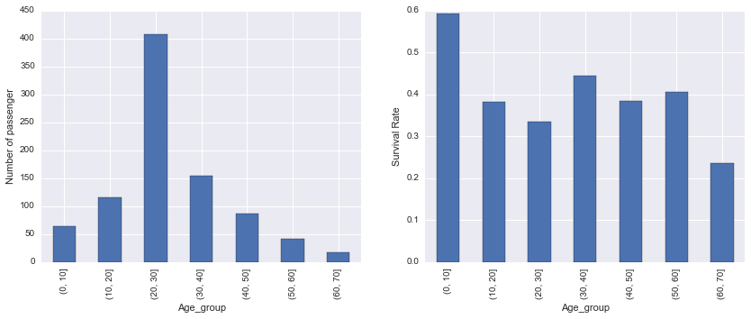

```python
## 将各年龄组的人数及生还率用柱状图表示
%pylab inline
plt.figure(figsize=(14,5))
plt.subplot(1,2,1)
titanic_data.groupby('Age_group')['Survived'].count().plot(kind='bar')
plt.ylabel('Number of passenger')
plt.subplot(1,2,2)
titanic_data.groupby('Age_group')['Survived'].mean().plot(kind='bar')
plt.ylabel('Survival Rate')
```

从图中可以看出，20-30岁的人数最多，但是0-10岁的生还率远高于其他组。也就是说小孩的生还率最高，约60%。

```python
## 是否生还与年龄的相关性，用survived代表是否生还的结果（因变量y），age代表年龄（自变量x）
def correlation(x, y):

    std_x = (x-x.values.mean())/x.std(ddof=0)
    std_y = (y-y.values.mean())/y.std(ddof=0)

    return (std_x*std_y).mean()
survived = titanic_data['Survived']
age = titanic_data['Adjusted_age']
correlation(age,survived)
```

```
-0.06491041993052603
```

从相关性上看，有很弱的负相关性。

```python
## 计算是否生还与车票费用的相关性
correlation(titanic_data['Survived'],titanic_data['Fare'])
```

```
0.257306522384962
```

可以看出车票费用与是否生还有一定的正相关性。

### 2.3等级Pclass与生还率

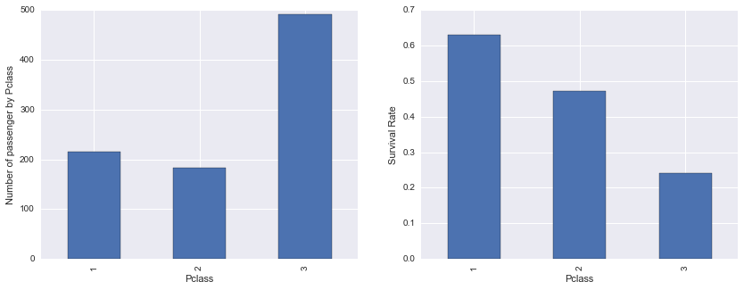

```python
## 查看是否生还与Pclass的关系,首先用count计算各个等级的总人数,再用均值mean计算各个等级的生还率，用柱状图表示如下
plt.figure(figsize=(14,5))
plt.subplot(1,2,1)
titanic_data.groupby('Pclass')['Survived'].count().plot(kind='bar')
plt.ylabel('Number of passenger by Pclass')
plt.subplot(1,2,2)
titanic_data.groupby('Pclass')['Survived'].mean().plot(kind='bar')
plt.ylabel('Survival Rate')
```

综合两张图可以看出，虽然阶层3的人数最多，但是其生还率反而是最低的。从阶层1到阶层3，生还率依次降低。阶层3的生还率不到30%。

## 3、初步结论

```python
## 用线性回归模型来计算一下是否生还与年龄、性别、车票费用、车厢等级Pclass的关系。
import pandas as pd
import statsmodels.api as sm
y = survived
sex = (titanic_data['Sex']=='male').astype('int')
pclass = pd.get_dummies(titanic_data['Pclass'],prefix='Pclass')
fare = titanic_data['Fare']
X = pd.concat([pclass,age,sex,fare],axis=1)
X=sm.add_constant(X)
est=sm.OLS(y,X)
est=est.fit()
est.summary()
```

OLS Regression Results

| Dep. Variable: | Survived | R-squared: | 0.383 |
| --- | --- | --- | --- |
| Model: | OLS | Adj. R-squared: | 0.380 |
| Method: | Least Squares | F-statistic: | 110.0 |
| Date: | Sun, 05 Mar 2017 | Prob (F-statistic): | 2.22e-90 |
| Time: | 22:01:37 | Log-Likelihood: | -406.65 |
| No. Observations: | 891 | AIC: | 825.3 |
| Df Residuals: | 885 | BIC: | 854.1 |
| Df Model: | 5 |  |  |
| Covariance Type: | nonrobust |  |  |

|  | coef | std err | t | P>\|t\| | [95.0% Conf. Int.] |
| --- | --- | --- | --- | --- | --- |
| const | 0.6791 | 0.032 | 21.532 | 0.000 | 0.617 0.741 |
| Pclass_1 | 0.4057 | 0.032 | 12.490 | 0.000 | 0.342 0.469 |
| Pclass_2 | 0.2313 | 0.024 | 9.710 | 0.000 | 0.185 0.278 |
| Pclass_3 | 0.0422 | 0.018 | 2.343 | 0.019 | 0.007 0.077 |
| Adjusted_age | -0.0049 | 0.001 | -4.638 | 0.000 | -0.007 -0.003 |
| Sex | -0.4980 | 0.028 | -18.026 | 0.000 | -0.552 -0.444 |
| Fare | 9.82e-05 | 0.000 | 0.300 | 0.764 | -0.001 0.001 |

| Omnibus: | 36.128 | Durbin-Watson: | 1.914 |
| --- | --- | --- | --- |
| Prob(Omnibus): | 0.000 | Jarque-Bera (JB): | 39.626 |
| Skew: | 0.514 | Prob(JB): | 2.49e-09 |
| Kurtosis: | 3.106 | Cond. No. | 1.45e+17 |

从t检验可以看出在95%的置信水平上，Pclass，Age，Sex都是统计显著的，Fare不显著。也就是说Pclass，Age，Sex都对是否生还有显著性影响。

## 4、思考及后续探索方向

以上是关于titanic数据的初步探索，其中age缺失值用了中值median填充，从本次的结果来看，用中值填充使得数据更集中，并不能确定是否是个有效的方法，需要在后续的探索中验证。另外，此数据集只有891条记录，不到总数据集的一半，年龄中有接近20%数据缺失，虽然用中值填充，却也很难保证它的合理性，更不能保证由此得出的结论的正确性。而且此次探索只涉及了年龄、性别、Pclass等级、费用这四个方面，得出的Rsqure只有0.38，可见并不能很好的解释结果，其他因素尚未进行探索，如兄弟姐妹个数，Embarked，以及一些未进行记录的参数，如身体状况等，都有可能影响最终的结果。